# Experimentação e Inferência Causal

Estamos encapsulando a discussão sobre comunicação em uma etapa apenas para garantir uma reflexão mais profunda, pois comunicação é algo realmente transversal a nossa rotina, visto que nos previne dos nossos pontos cegos, amplia nossas percepções, e, consequentemente, aumenta a qualidade das nossas entregas. De modo geral, comunicação nos economiza tempo!

# Bibliotecas

```r
library(tidyverse)
```

# Introdução

Nesta etapa focamos no que será feito a partir de todo o conhecimento obtido, quão efetiva é a ação aplicada? Se tivermos identificado clientes que alta propensão à abandonar o nosso serviço, por exemplo, é natural que queiramos aplicar ações preventivas, visando evitar esta saída. Mas como saber se estamos tomando ações efetivas? Como mensurar tal efeito de forma fundamentada? A resposta: utilizando pensamento científico, por meio de experimentações, controle de fatores externos, e mensuração de resultados!

# Experimentação

Em linhas gerais, conduzimos um experimento quando criamos uma situação, mas não temos certeza quanto as consequências que a situação implica, e gostaríamos de entender e mensurar o efeito desta ação. Ao falar de experimentos, estamos nos referindo a experimentos controlados, na indústria de tecnologia usualmente conhecidos por meio dos testes A/B. Considerando um cenário mais tradicional, temos que a experimentação se dá pela: segmentação do público a ser testado em dois grupos, ambos equivalentes e comparáveis, salvo pela aplicação da ação que queremos mensurar em um destes grupos, o grupo de ação, enquanto mantemos o segundo grupo, denominado o grupo controle ou placebo, preservado (ou ainda: grupo A e grupo B). De modo que, visto os grupos serem equivalentes exceto pela ação a ser aplicada em um e não em outro grupo, qualquer diferença observada entre tais grupos será atribuída a ação aplicada.

# Discussão de um case

Para ilustrar de forma mais palpável sobre a importância de experimentações, considere o caso de uma empresa de telecomunicações, também conhecida como TELECOM, que possui o interesse em garantir a convergência entre os seus serviços de assinatura de tv, internet fixa e serviços de telefonia móveis, isto é, a empresa tem como interesse que clientes que já utilizem algum de seus serviços, passem a contratar os demais serviços oferecidos, no caso: tv, internet residencial e celular. Vamos supor que um modelo já nos indique quais clientes que são mais propensos a contratação dos três serviços quando recebem uma oferta de desconto para tal, contudo, não sabemos quanto de desconto precisa ser dado. Aqui podemos utilizar a experimentação como recurso!

- Primeiramente precisamos refletir no problema que nos propomos a resolver, considerando o conhecimento, ferramentas e dados disponíveis. No caso, poderíamos ter que faixas de desconto variando entre 5 e 15% seriam valores possíveis de serem considerados, visando facilitar o exemplo, vamos considerar que seriam testados três faixas de desconto: 5, 10 e 15%, além do 0%, que nos daria a referência do que aconteceria se não aplicássemos qualquer desconto. No mais, para a avaliação dos efeitos, poderíamos, por exemplo, comparar o percentual de clientes de cada grupo que aderiram os três serviços após receber a oferta;
- De modo que teríamos como possíveis hipóteses: oferecer descontos aumenta a taxa de contratação dos três serviços, ou ainda, quanto maior o percentual de desconto oferecido, maior o percentual de clientes contratando os serviços desejados;
- Refletindo sobre possíveis fatores de influência, isto é, procurando identificar aspectos que poderiam vir a influencias os resultados que temos o interesse em mensurar, podemos levantar fatores como: a diferenciação entre clientes que só possuem um serviço, daqueles que já possuem dois serviços, o que pode tornar o segundo grupo mais propício a contratarem os três serviços;
- Em relação a especificação do experimento, de modo a garantir comparabilidade e a minimização de possíveis ruídos aleatórios, além da consideração dos grupos acima, podemos especificar a forma como os clientes seriam notificados do desconto, ou ainda algum cuidado para garantir que não acabem caindo em outra “régua de promoção”, ou outros fatores, que poderiam enviesar o resultado. Nos levando a acreditar que o efeito dos descontos é maior ou menor do que realmente é;
- Assim, com a execução e avaliação dos efeitos, chegamos no questionamento: o experimento foi conclusivo? Isto é, conseguimos responder as hipóteses inicialmente postas? Se sim, ótimo! Caso não, precisamos entender melhor os porquês, identificar possíveis vieses que não foram devidamente controlados e reiniciar o fluxo, garantindo um cenário mais consistente que o último. Poderíamos por exemplo, concluir que houve um desbalanceamento nos grupos de clientes com apenas um serviço já contratado, tendo que para aqueles que receberam a faixa de desconto de 5% havia uma quantidade maior de clientes com o serviço mais barato já contratado, o que pode tornar a faixa de 5% menos atrativa, devido ao valor absoluto resultante do desconto. Assim, em uma nova rodada do experimento, teríamos um maior controle na questão dos serviços já contratados por cada cliente.

Estamos aqui comentando sobre uma aplicação mais genérica, tendo como intenção elucidar a lógica da experimentação. Porém, para um maior aprofundamento, é importante comentar que, a depender de qual área a experimentação estiver sendo aplicada, podemos encontrar denominações diferentes, como: Ensaio Clínico, DOE (do inglês, design of experiments, em português: Planejamento de Experimentos), ou mesmo o Teste A/B, que passa a ser denominado como Testes Multivariados, quando prevê mais de dois cenários. E apesar de cada um destes termos terem especificidades próprias, todas contemplam a investigação sistemática por meio do método científico

# E no R?

Para garantir que este processo seja conclusivo, ferramentas e conceitos provenientes de áreas como:

- inferência estatística: como testes de hipótese e avaliação comportamentos esperados vs. amostras observadas, entender o modelo populacional subjacente;
- amostragem: viés e segmentação da população em estratos; ou
- planejamento de experimentos: variáveis de confusão

são essenciais para auxiliar o cientista nas definições e acompanhamentos apropriados ao longo de todo o processo. E visto o R ter origem na estatística, e existirem temos muitas opções de funções e pacotes para tais temas

# Notes

# Case

Para demonstrar, percorreremos um pipeline de inferência típico passo a passo. Ao longo deste post, fazemos uso do gss, um conjunto de dados fornecido pela infer contendo uma amostra de 500 observações de 11 variáveis do General Social Survey.

Subconjunto de dados do Inquérito Social Geral (GSS). Descrição O General Social Survey é um levantamento de alta qualidade que reúne dados sobre a sociedade e opiniões americanas, realizado desde 1972. Este conjunto de dados é uma amostra de 500 entradas do GSS, abrangendo os anos 1973-2018, incluindo marcadores demográficos e algumas variáveis econômicas. Observe que esses dados são incluídos apenas para demonstração e não devem ser considerados como estimativas precisas relacionadas ao GSS. No entanto, devido à alta qualidade do GSS, os dados não ponderados se aproximarão dos dados ponderados em algumas análises.

```r
library(infer)

gss <- gss %>% glimpse()
```

```
## Rows: 500
## Columns: 11
## $ year    <dbl> 2014, 1994, 1998, 1996, 1994, 1996, 1990, 2016, 2000, 1998, 20…
## $ age     <dbl> 36, 34, 24, 42, 31, 32, 48, 36, 30, 33, 21, 30, 38, 49, 25, 56…
## $ sex     <fct> male, female, male, male, male, female, female, female, female…
## $ college <fct> degree, no degree, degree, no degree, degree, no degree, no de…
## $ partyid <fct> ind, rep, ind, ind, rep, rep, dem, ind, rep, dem, dem, ind, de…
## $ hompop  <dbl> 3, 4, 1, 4, 2, 4, 2, 1, 5, 2, 4, 3, 4, 4, 2, 2, 3, 2, 1, 2, 5,…
## $ hours   <dbl> 50, 31, 40, 40, 40, 53, 32, 20, 40, 40, 23, 52, 38, 72, 48, 40…
## $ income  <ord> $25000 or more, $20000 - 24999, $25000 or more, $25000 or more…
## $ class   <fct> middle class, working class, working class, working class, mid…
## $ finrela <fct> below average, below average, below average, above average, ab…
## $ weight  <dbl> 0.8960034, 1.0825000, 0.5501000, 1.0864000, 1.0825000, 1.08640…
```

```r
# encontre a estimativa pontual --- número médio de horas trabalhadas por semana

(point_estimate <- gss %>%
  specify(response = hours) %>%
  calculate(stat = "mean"))
```

```
## Response: hours (numeric)
## # A tibble: 1 × 1
##    stat
##   <dbl>
## 1  41.4
```

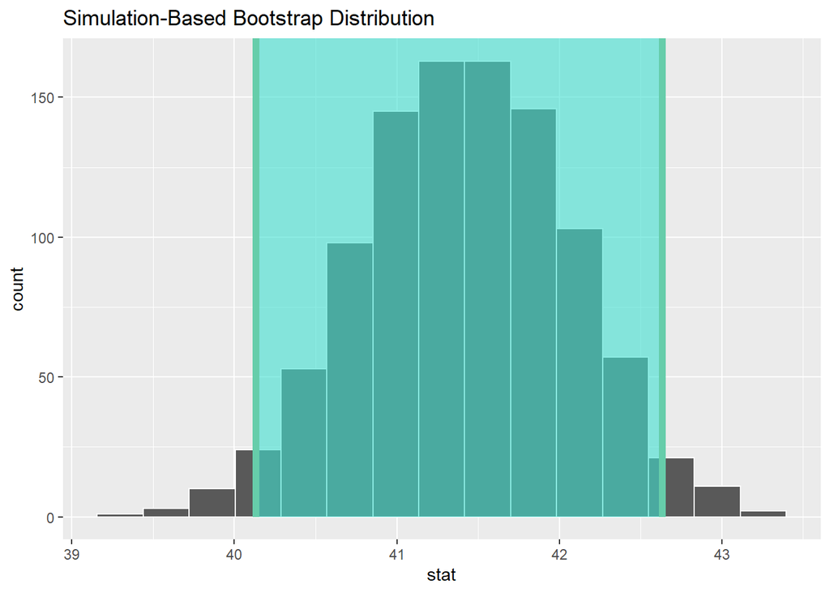

```r
# ...and a bootstrap distribution
boot_dist <- gss %>%
  # ...we're interested in the number of hours worked per week
  specify(response = hours) %>%
  # generating data points
  generate(reps = 1000, type = "bootstrap") %>%
  # finding the distribution from the generated data
  calculate(stat = "mean")


# find a confidence interval around the point estimate
ci <- boot_dist %>%
  get_confidence_interval(point_estimate = point_estimate,
                          # at the 95% confidence level
                          level = .95,
                          # using the standard error method
                          type = "se")

# and plot it!
boot_dist %>%
  visualize() +
  shade_confidence_interval(ci)
```

```r
(p_value <- boot_dist %>%
  get_p_value(obs_stat = point_estimate, direction = "two-sided"))
```

```
## # A tibble: 1 × 1
##   p_value
##     <dbl>
## 1    0.95
```

```r
(conf_ints <- boot_dist %>%
  get_confidence_interval(
    point_estimate = point_estimate,
    level = 0.95,
    type = "se"
  ) )
```

```
## # A tibble: 1 × 2
##   lower_ci upper_ci
##      <dbl>    <dbl>
## 1     40.1     42.6
```

Para ilustrar, voltaremos ao exemplo de determinar se o número médio de horas trabalhadas por semana é de 40 horas.

Nossa estimativa pontual 41.382 parece bem próxima de 40, mas um pouco diferente. Podemos nos perguntar se essa diferença se deve apenas ao acaso ou se o número médio de horas trabalhadas por semana na população realmente não é 40.

Inicialmente, poderíamos apenas visualizar a distribuição.

> exemplo retirado do [post](https://infer.netlify.app/reference/shade_confidence_interval.html)